# Parcial 1

Nelson Fabian Alzate, Jhon Faber Linares

2022-03-24

## Punto 1

1. La tabla mostrada contiene valores de población, en cientos de miles, de las diez ciudades más pobladas de cuatro países en el año 1967:

**Datos**

| **Argentina** | **EE.UU** | **Holanda** | **Japón** |
| --- | --- | --- | --- |
| 29.66 | 77.81 | 8.68 | 110.21 |
| 7.61 | 35.50 | 7.31 | 32.14 |
| 6.35 | 24.79 | 6.02 | 18.88 |
| 4.10 | 20.02 | 2.64 | 16.38 |
| 3.80 | 16.70 | 1.75 | 13.37 |
| 2.75 | 9.39 | 1.72 | 11.92 |
| 2.70 | 9.38 | 1.51 | 10.71 |
| 2.69 | 8.76 | 1.42 | 7.80 |
| 2.51 | 7.63 | 1.31 | 7.70 |
| 2.44 | 7.50 | 1.29 | 7.00 |

## a) Blot-plots

Construya un box-plot e identifique los puntos extremos. ¿Cuáles son las características más sobresalientes? ¿Hay outliers?

Se realiza por cada pais una grafica de cajas y bitgotes

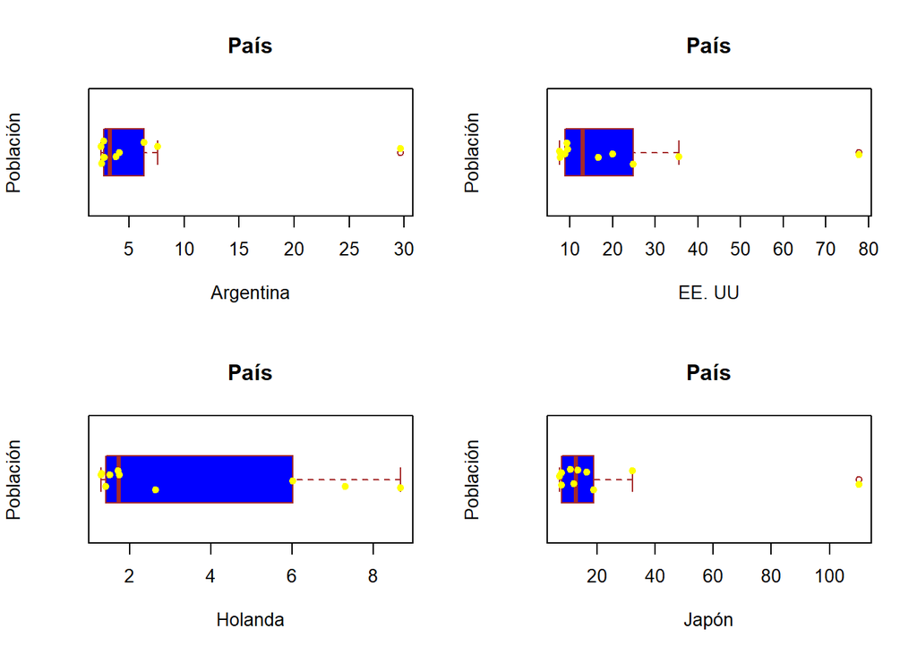

### Interpretación :

Hay datos atipicos en los paises de Argentina, EE.UU y Japón.En Holanda los datos estan agrupados entre el Q1 y Q3 lo que representa el 50%.

Argentina, Holanda y EE.UU tiene Asimetria positiva pues la media esta mas cerca del Q1

## b)

Compare los centros de cada población, sus dispersiones y su simetría. ¿Cuál es el país más homogéneamente habitado? ¿Cuáles son las características más sobresalientes? ¿Hay outliers?

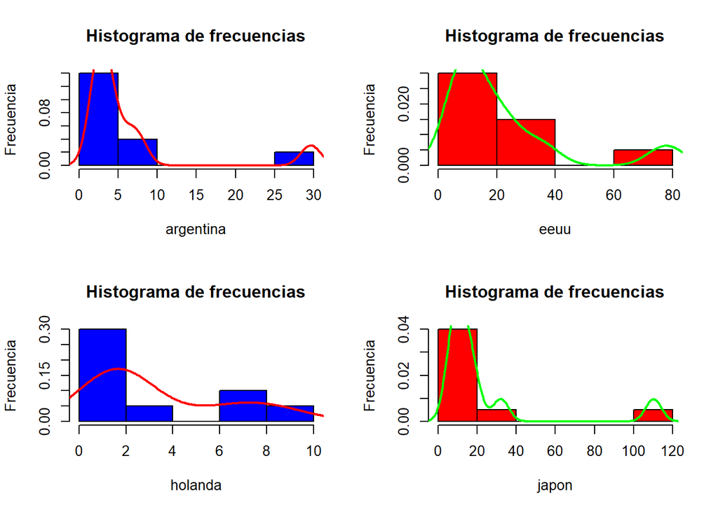

### Analisis de las gráficas

### Interpretación B:

Holanda se puede observar que tiene poca dispersion en los datos. Japon es el pais con mucha dispersion en sus datos Holanda no tiene datos atipicos compada con los otros paises.

El coficiente de simetria sk = 2.4566523 para la gráfica de *Argentina*, esta es de asimetría positiva y con curtosis según el coeficiente  
cu = 7.4192345 de tipo leptocurtica, lo que quiere decir que existen muchos valores concentrados entorno a su media.

El coficiente de simetria sk = 1.9086222 para la gráfica de *EE.UU*, esta es de asimetría positiva y con curtosis según el coeficiente  
cu = 5.5847302 de tipo leptocurtica, lo que quiere decir que existen muchos valores concentrados entorno a su media.

El coficiente de simetria sk = 2.4078156 para la gráfica de *Japon*, esta es de asimetría positiva y con curtosis según el coeficiente  
cu = 7.241345 de tipo leptocurtica, lo que quiere decir que existen muchos valores concentrados entorno a su media.

### Punto 2

Avianca se encuentra estudiando la situación de venta de puesto en el vuelo Armenia – Bogotá puesto que ha identificado que el 2% de las personas que reservaron puesto, no se presentan a la hora del embarque. Teniendo en cuenta que el avión A320 utilizado en esta ruta tiene una capacidad para 180 pasajeros, la empresa decide vender 181 tiquetes. ¿Cuál es la probabilidad de que todas las personas que llegan a embarque puedan tener su silla asegurada y no se presenten quejas por “sobre-vender” sillas ante la aeronáutica civil? Asuma que las llegadas de los pasajeros siguen una distribución Poisson.

```
## [1] 0.653453
```

[figure not shown]

### Interpretación

la probabilidad de que todas las personas que llegan a embarque y tengan una silla asegurada y no se vayan a presentar quejas por “sobre-vender” es 65.3452953 %

### Punto 3

En la planta envasadora de Coca-Cola FEMSA ubicada en Tocancipá se realiza el embotellado de la CocaCola presentación de 400 mL (en promedio), con una desviación estándar de 5 mL (mililitros). Si se sabe por experiencia que este proceso de embotellado sigue una distribución normal, y también se sabe que todo producto con más de 415 mL es declarado como NO CONFORME. Determine el porcentaje de las botellas de gaseosa que son declaradas producto NO CONFORME.

# Datos:

Media= 400

Desviación estandar = 5

```
## [1] 0.001349898
```

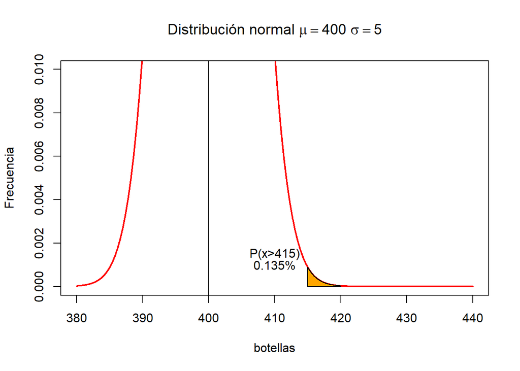

### Interpretación

El porcentaje de las botellas de gaseosa que son declaradas producto NO CONFORME es de un 0.135%